# Getting Started with szKendall

## Overview

The goal of szKendall is to measure the dissimilarity between two single cells based on their observed Hi-C data, accounting for the discrepancies in structural zero positions. This rank-based dissimilarity measure can be powerful for single-cell Hi-C clustering and other downstream analyses. The calculation is implemented using Rcpp for speed and supports parallel computation via `foreach` and `doParallel` packages.

## Installation

You can install the szKendall package from GitHub:

```r
# If not already installed:
# install.packages("devtools")

# library(devtools)
# devtools::install_github("https://github.com/osu-stat-gen/szKendall")
suppressPackageStartupMessages({
  library(ggplot2)
  library(plsgenomics)
  library(dplyr)
  library(Rtsne)
  library(umap)
  library(szKendall)
})
```

You may also need to load parallel backends:

```r
suppressPackageStartupMessages({
library(doParallel)
library(foreach)
})
registerDoParallel(cores = 4)
# Run foreach::registerDoSEQ() to override any parallel backend and force sequential calculation
# foreach::registerDoSEQ()
```

## Example: Calculating szKendall Dissimilarity and Perform Clustering

This is an example which shows you how to calculate the szKendall dissimilarity between cells. The simulated data contain 150 single cells (i.e., 150 columns). Therefore, the resulting szKendall matrix (which is symmetric with the main-diagonal all being 0) is of dimension 150 by 150. The $(i, j)^{th}$ element in this matrix indicates the szKendall dissimilarity between cell $i$ and cell $j$.

```r
# Simulated data (or real, observed count data)
data("sim1.data")
# Underlying expected count
# (where only structural zeros are exactly zeros; all other positions have positive values)
data("true1.data")

# DOs are imputed
contacts <- sim1.data
contacts[true1.data!=0] <- true1.data[true1.data!=0]

# Calculate szKendall dissimilarity, along with its two variants
```

The `szKendall()` function supports three input formats:

1. A **#LP × #cells** numeric matrix
2. A **list** of length **#cells**, where each element is a symmetric Hi-C count matrix of dimension **#LP X #LP**
3. A **3D array** of dimension **#LP X #LP X #cells**, where each slice corresponds to a symmetric Hi-C count matrix.

The argument `dist.method` specifies the weighting scheme and accepts either  
`"szKendall"` or `"szKendall1"`.

See `?szKendall` for further details.

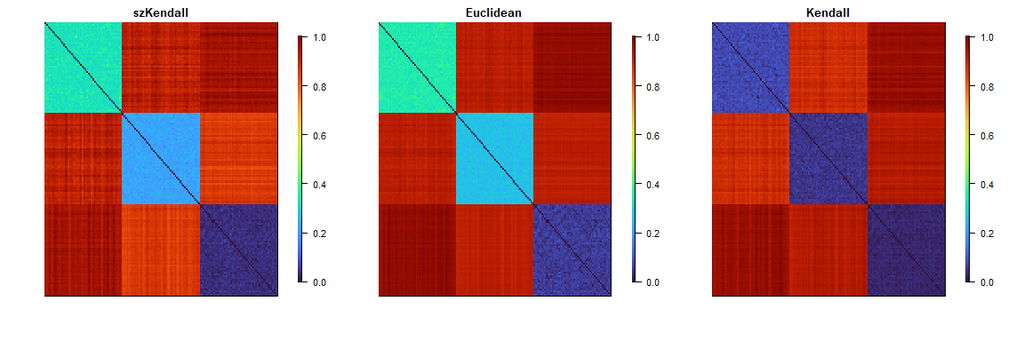

```r
szK  <- szKendall(contacts=contacts,dist.method="szKendall",heatmap=TRUE)
```

Also, if `heatmap = TRUE`, the function will automatically generate heatmaps of the resulting **szKendall(1)**, **Euclidean**, and **Kendall** dissimilarity matrices.

```r
szK1 <- szKendall(contacts=contacts,dist.method="szKendall1")
```

`scHiC_hm_dist()` also provides convenient visualization tools for the dissimilarity matrices.

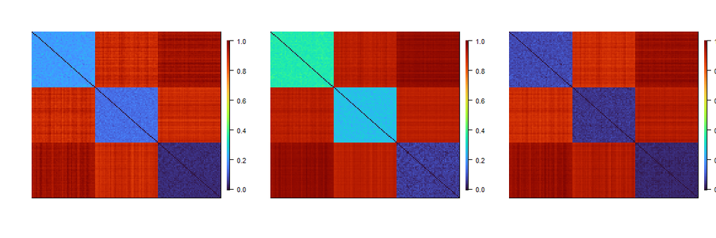

```r
par(mfrow=c(1,3))
scHiC_hm_dist(szK1[[1]]) # szKendall(1)
scHiC_hm_dist(szK1[[2]]) # Euclidean
scHiC_hm_dist(szK1[[3]]) # Kendall
```

The `szKendall` package additionally offers 2D visualization tools, such as t-SNE (`scHiC_tSNE_dist()`) and UMAP (`scHiC_UMAP_dist()`) projections of the dissimilarity matrix.

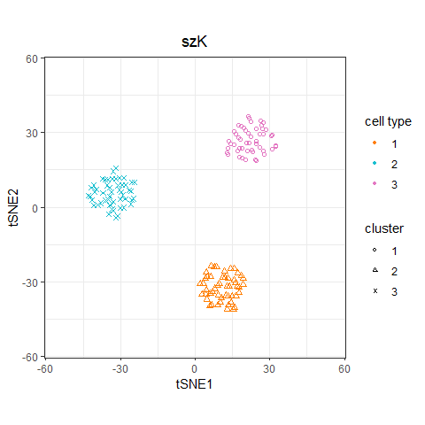

```r
# Specify the true cell labels
n_single <- 50
cell.type <- factor(c(rep(1,n_single), rep(2,n_single), rep(3,n_single)), levels=c("1", "2", "3"))

# t-SNE 2D projection
scHiC_tSNE_dist(szK[[1]], cell_type=cell.type, seed=1234, title="szK", alpha_value=1)
```

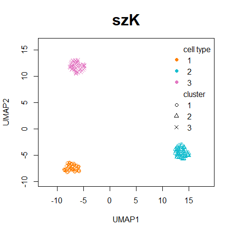

```r
# UMAP 2D projection
scHiC_UMAP_dist(szK[[1]], cell_type=cell.type, seed=1234, main="szK", alpha_value=1)
```

Using a dissimilarity matrix (Euclidean, szKendall, or others), we can perform clustering and measure the clustering results using the four criterion values (ARI, WSS%, ASW, and MIS). Below is an example of performing K-means, PAM, & hierarchical clustering based on the Euclidean distance on the simulated data, and performing PAM & hierarchical clustering based on the szKendall dissimilarity.

```r
suppressWarnings({
  suppressPackageStartupMessages({
    library(cluster)  # required to perform PAM clustering
    library(factoextra)  # required to perform hierarchical clustering
  })
})

euclid.sim1 <- as.matrix(dist(t(scale(sim1.data))))
rownames(euclid.sim1) <- NULL
colnames(euclid.sim1) <- NULL

#------------------------------------- K-means --------------------------------------------------------

##  Perform K-means clustering on the simulated data (which is based on Euclidean distance)  ##

set.seed(1234)
km1 <- kmeans(t(scale(sim1.data)), centers=3, nstart=10, iter.max=100, algorithm="Hartigan-Wong")

# ARI (adjusted rand index)
ARI(cell.type, km1$cluster)
```

```
#> [1] 0.979932
```

```r
# WSS% (within-cluster sum of squares percentage)
# The 'WSS_percentage_kmeans()' function is designed specifically for "kmeans" object,
# and the returned WSS% value should be identical to the one returned by 'WSS_percentage()' function.
WSS_percentage_kmeans(km1)
```

```
#> [1] 0.9695283
```

```r
WSS_percentage(km1$cluster, euclid.sim1)
```

```
#> [1] 0.9695283
```

```r
# ASW (average silhouette width)
ASW(km1$cluster, euclid.sim1)
```

```
#> [1] 0.01022421
```

```r
# MIS (minimum isolation score)
MIS(km1$cluster, euclid.sim1)
```

```
#> [1] 0.8931245
```

```r
#--------------------------------------- PAM ----------------------------------------------------------

##  Perform PAM clustering on the simulated data (which is based on Euclidean distance)  ##
set.seed(1234)
pam1 <- pam(euclid.sim1, k=3, nstart=10, diss=TRUE)
# ARI
ARI(cell.type, pam1$clustering)
```

```
#> [1] -0.003371085
```

```r
# WSS%
WSS_percentage(pam1$clustering, euclid.sim1)
```

```
#> [1] 0.9843385
```

```r
# ASW
# (the ASW extracted from 'pam1$silinfo$avg.width' should be identical to the one returned by 'ASW' function.)
ASW(pam1$clustering, euclid.sim1)
```

```
#> [1] 0.0003360744
```

```r
pam1$silinfo$avg.width
```

```
#> [1] 0.0003360744
```

```r
# MIS
MIS(pam1$clustering, euclid.sim1)
```

```
#> [1] 0.8745308
```

```r
##  Perform PAM clustering on the simulated data + true SZ information (which is based on szKendall)  ##
set.seed(1234)
pam2 <- pam(szK[[1]], k=3, nstart=10, diss=TRUE)
# ARI
ARI(cell.type, pam2$clustering)
```

```
#> [1] 1
```

```r
# WSS%
WSS_percentage(pam2$clustering, szK[[1]])
```

```
#> [1] 0.1289283
```

```r
# ASW
# (the ASW extracted from 'pam2$silinfo$avg.width' should be identical to the one returned by 'ASW' function.)
ASW(pam2$clustering, szK[[1]])
```

```
#> [1] 0.7170646
```

```r
pam2$silinfo$avg.width
```

```
#> [1] 0.7170646
```

```r
# MIS
MIS(pam2$clustering, szK[[1]])
```

```
#> [1] 1.90289
```

```r
#------------------------------------ Hierarchical ----------------------------------------------------

##  Perform Hierarchical clustering on the simulated data (which is based on Euclidean distance)  ##
set.seed(1234)
hclust1 <- hcut(as.dist(euclid.sim1), hc_func="hclust", hc_method="complete", k = 3, isdiss = TRUE)
# ARI
ARI(cell.type, hclust1$cluster)
```

```
#> [1] 0.2584762
```

```r
# WSS%
WSS_percentage(hclust1$cluster, euclid.sim1)
```

```
#> [1] 0.9791586
```

```r
# ASW
# (the ASW extracted from 'hclust1$silinfo$avg.width' should be identical to the one returned by 'ASW' function.)
ASW(hclust1$cluster, euclid.sim1)
```

```
#> [1] 0.0001513779
```

```r
hclust1$silinfo$avg.width
```

```
#> [1] 0.0001513779
```

```r
# MIS
MIS(hclust1$cluster, euclid.sim1)
```

```
#> [1] 0.8903992
```

```r
##  Perform Hierarchical clustering on the simulated data + true SZ information (which is based on szKendall)  ##
set.seed(1234)
hclust2 <- hcut(as.dist(szK[[1]]), hc_func="hclust", hc_method="complete", k = 3, isdiss = TRUE)
# ARI
ARI(cell.type, hclust2$cluster)
```

```
#> [1] 1
```

```r
# WSS%
WSS_percentage(hclust2$cluster, szK[[1]])
```

```
#> [1] 0.1289283
```

```r
# ASW
# (the ASW extracted from 'hclust2$silinfo$avg.width' should be identical to the one returned by 'ASW' function.)
ASW(hclust2$cluster, szK[[1]])
```

```
#> [1] 0.7170646
```

```r
hclust2$silinfo$avg.width
```

```
#> [1] 0.7170646
```

```r
# MIS
MIS(hclust2$cluster, szK[[1]])
```

```
#> [1] 1.90289
```

```r
# ARI
MIS(hclust2$cluster, szK[[1]])
```

```
#> [1] 1.90289
```

## Simulate single-cell Hi-C Data

In this package, we also provide a function that simulates the single-cell Hi-C data for `n_single` cells of the same cell (sub)type, given the 3D coordinates of `n` loci. The underlying expected contact count data are also returned, which indicate all the structural zero positions (i.e., those positions with expected count being 0).

```r
# Simulate the data for 50 cells
n_single <- 50
# Load the 3D coordinates of n=61 loci
data("coord3D_T1")

# Save the resulting data as ST1 (subtype 1), which contains the simulated and expected contact counts
# (Both matrices are of dimension 1830 by 50, where 1830 = 61*60/2 is the number of locus pairs,
#  and 50 is the number of cells (n_single). )
set.seed(1234)
ST1 <- scHiC_simulate_withoutdiagonal(
  data = coord3D_T1,
  alpha_0 = 1.8,
  alpha_1 = -1,
  beta_l = 0.9,
  beta_g = 0.9,
  beta_m = 0.9,
  gamma = 0.6,
  tau1 = 0.7,
  eta = 0.1,
  tau2=0.6,
  n_single=n_single
)
dim(ST1$singledat)
```

```
#> [1] 1830   50
```

```r
dim(ST1$truecount)
```

```
#> [1] 1830   50
```

### Explanation of Parameters

- `data` is an `n` by 3 matrix representing the 3D coordinates of `n` loci.
- `alpha_0` controls the sequencing depth of the simulated single-cell Hi-C data.
- `alpha_1` reflects the biophysical law between the expected contact counts and the 3D Euclidean distances among the loci. Default value is -1.
- `beta_l` mimics the effect of fragment length in generating single-cell Hi-C data. Default value is 0.9.
- `beta_g` mimics the effect of GC content in generating single-cell Hi-C data. Default value is 0.9.
- `beta_m` mimics the effect of mappability in generating single-cell Hi-C data. Default value is 0.9.
- `gamma` defines the threshold for expected contact counts; locus pairs with expected counts below this percentile could become structural zero candidates.
- `tau1` sets the probability that a locus pair with expected count below `gamma` percentile turning into a structural zero candidate.
- `eta` decides the proportion of common structural zeros among the structural zero candidates.
- `tau2` decides the proportion of cell-specific structural zeros among the remaining `1 - eta` proportion of the structural zero candidates.
- `n_single` is the number of single cells (i.e., columns) to be generated.

### Explanation of Output

`scHiC_simulate_withoutdiagonal()` returns a list with 2 elements:

- `singledat`: The simulated single-cell Hi-C contact counts. The dimension is `N` by `n_single`, where `N = n*(n-1)/2` is the number of unique locus pairs given `n` loci.
- `truecount`: The expected (“true”) single-cell Hi-C contact counts. Same dimension as `singledat`.